# Basis of Record Analysis

Sweden - GBIF Data Gap Assessment

March 17, 2026

# Overview

This report analyses **how different types of biodiversity observations** contribute to GBIF data coverage in Sweden. Understanding the composition of the data by basis of record is essential for identifying biases and planning targeted data mobilisation efforts.

GBIF distinguishes several basis-of-record categories, each representing a different method of documenting biodiversity:

- **Human Observation** - direct field sightings (e.g. citizen science, bird surveys)
- **Preserved Specimen** - museum and herbarium collections
- **Machine Observation** - camera traps, acoustic sensors, remote sensing
- **Material Sample** - DNA, tissue, environmental samples
- **Fossil Specimen** - palaeontological records
- **Living Specimen** - botanical gardens, zoos

```r
# Spatial gaps (cell-level, all basis types)
spatial_gaps <- safe_read(here(p_gaps, paste0("spatial_gaps_", params$grid, ".csv")))

# Time summary
time_summary <- safe_read(here(p_derived, paste0("time_summary_", params$grid, ".csv")))
if (!is.null(time_summary)) {
  time_summary[, yearmonth_chr := str_trim(as.character(yearmonth))]
  time_summary[, ym_valid := str_detect(yearmonth_chr, "^[0-9]{4}-[0-9]{2}$")]
  time_summary[, year := fifelse(ym_valid, as.integer(str_sub(yearmonth_chr, 1, 4)), NA_integer_)]
  time_summary[, month := fifelse(ym_valid, as.integer(str_sub(yearmonth_chr, 6, 7)), NA_integer_)]
  time_summary[, c("yearmonth_chr", "ym_valid") := NULL]
}

# Temporal by basis
temporal_by_basis <- safe_read(here(p_gaps, paste0("temporal_year_by_basis_", params$grid, ".csv")))

# Taxonomic coverage by basis
tax_by_basis <- safe_read(here(p_gaps, "taxonomic_coverage_by_basis.csv"))

# Grid for maps
grid_sf <- tryCatch({
  # Try processed gpkg first (from script 02), then raw shapefile
  gpkg_path <- here(p_data_proc, paste0("grids_", grid_suffix, ".gpkg"))
  if (file.exists(gpkg_path)) {
    g <- st_read(gpkg_path, quiet = TRUE)
  } else {
    grid_dir  <- here(cfg$paths[[paste0("grid_", grid_suffix, "_dir")]])
    grid_file <- cfg$files$grids[[paste0("grid", grid_suffix)]]
    g <- st_read(here(grid_dir, grid_file), quiet = TRUE)
  }

  # Standardise cell ID column (same pattern as 00_setup.R / globals.R)
  cellcode_field <- names(g)[grepl("cellcode|eeacell", tolower(names(g)))][1]
  if (is.na(cellcode_field)) cellcode_field <- names(g)[grepl("code", tolower(names(g)))][1]
  if (!is.na(cellcode_field)) g$eeacellcode <- as.character(g[[cellcode_field]])
  g
}, error = function(e) NULL)

# Cell summary for total cell count
cell_summary <- safe_read(here(p_derived, paste0("cell_summary_", params$grid, ".csv")))
total_cells <- if (!is.null(cell_summary)) uniqueN(cell_summary$eeacellcode) else
               if (!is.null(spatial_gaps)) uniqueN(spatial_gaps[basisofrecord == "all"]$eeacellcode) else NA
```

# Occurrence Volume by Basis of Record

## Total Occurrences

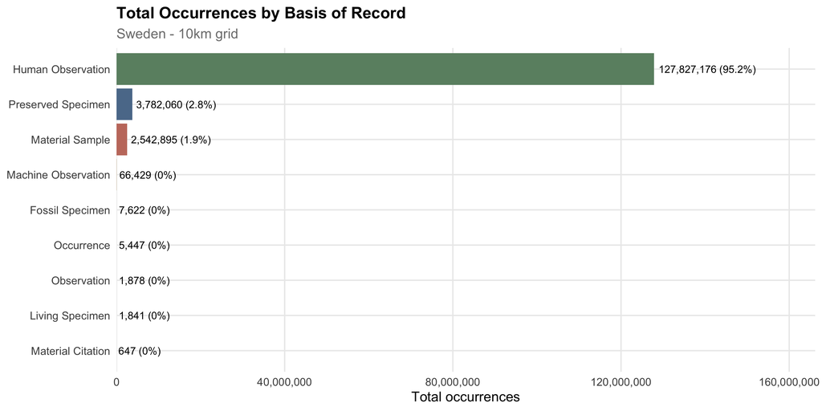

```r
if (!is.null(spatial_gaps)) {
  basis_totals <- spatial_gaps[basisofrecord != "all",
    .(total_occurrences = sum(as.numeric(occurrences), na.rm = TRUE),
      cells_with_data = sum(occurrences > 0, na.rm = TRUE),
      total_species = sum(as.numeric(n_species), na.rm = TRUE)),
    by = basisofrecord
  ][order(-total_occurrences)]

  basis_totals[, label := basis_label(basisofrecord)]
  basis_totals[, pct := round(100 * total_occurrences / sum(total_occurrences), 1)]

  ggplot(basis_totals, aes(x = reorder(label, total_occurrences), y = total_occurrences,
                            fill = basisofrecord)) +
    geom_col(show.legend = FALSE) +
    geom_text(aes(label = paste0(comma(total_occurrences), " (", pct, "%)")),
              hjust = -0.05, size = 3.2) +
    scale_fill_manual(values = basis_palette) +
    scale_y_continuous(labels = comma, expand = expansion(mult = c(0, 0.3))) +
    coord_flip() +
    labs(title = "Total Occurrences by Basis of Record",
         subtitle = paste0(country_name, " - ", params$grid, " grid"),
         x = NULL, y = "Total occurrences")
}
```

## Summary Table

```r
if (!is.null(spatial_gaps)) {
  basis_totals[, spatial_coverage := round(100 * cells_with_data / total_cells, 1)]

  basis_totals |>
    select(label, total_occurrences, pct, cells_with_data, spatial_coverage, total_species) |>
    rename(
      `Basis of Record` = label,
      `Total Occurrences` = total_occurrences,
      `% of All` = pct,
      `Cells with Data` = cells_with_data,
      `Spatial Coverage (%)` = spatial_coverage,
      `Species Detections` = total_species
    ) |>
    kable(format.args = list(big.mark = ","))
}
```

| Basis of Record | Total Occurrences | % of All | Cells with Data | Spatial Coverage (%) | Species Detections |
| --- | --- | --- | --- | --- | --- |
| Human Observation | 127,827,176 | 95.2 | 5,791 | 75.3 | 5,353,102 |
| Preserved Specimen | 3,782,060 | 2.8 | 5,711 | 74.2 | 1,756,824 |
| Material Sample | 2,542,895 | 1.9 | 3,391 | 44.1 | 221,428 |
| Machine Observation | 66,429 | 0.0 | 1,451 | 18.9 | 3,176 |
| Fossil Specimen | 7,622 | 0.0 | 263 | 3.4 | 1,041 |
| Occurrence | 5,447 | 0.0 | 1,212 | 15.8 | 3,212 |
| Observation | 1,878 | 0.0 | 38 | 0.5 | 1,568 |
| Living Specimen | 1,841 | 0.0 | 463 | 6.0 | 1,381 |
| Material Citation | 647 | 0.0 | 253 | 3.3 | 437 |

# Spatial Coverage

How well does each basis of record cover the spatial grid? A basis type that covers many cells provides broad geographic information, while one concentrated in few cells may reflect institutional or logistical biases.

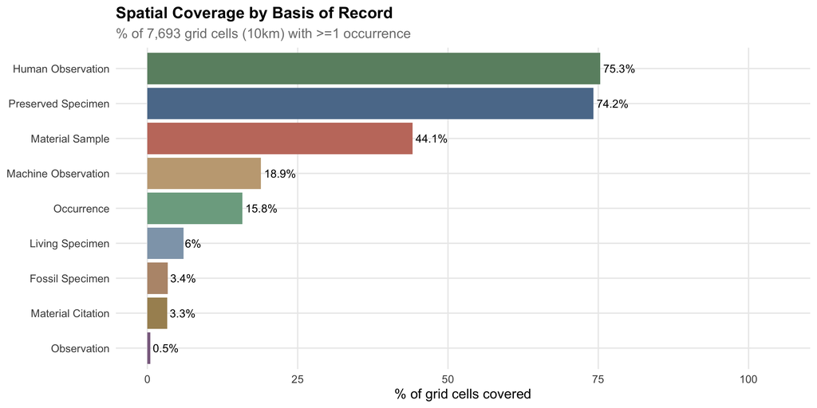

```r
if (!is.null(spatial_gaps)) {
  coverage_df <- spatial_gaps[basisofrecord != "all",
    .(cells_with_data = sum(occurrences > 0, na.rm = TRUE)),
    by = basisofrecord
  ][order(-cells_with_data)]

  coverage_df[, label := basis_label(basisofrecord)]
  coverage_df[, pct := round(100 * cells_with_data / total_cells, 1)]

  ggplot(coverage_df, aes(x = reorder(label, pct), y = pct, fill = basisofrecord)) +
    geom_col(show.legend = FALSE) +
    geom_text(aes(label = paste0(pct, "%")), hjust = -0.1, size = 3.5) +
    scale_fill_manual(values = basis_palette) +
    scale_y_continuous(limits = c(0, 105)) +
    coord_flip() +
    labs(title = "Spatial Coverage by Basis of Record",
         subtitle = paste0("% of ", comma(total_cells), " grid cells (", params$grid, ") with >=1 occurrence"),
         x = NULL, y = "% of grid cells covered")
}
```

```r
if (!is.null(spatial_gaps) && !is.null(grid_sf) && "eeacellcode" %in% names(grid_sf)) {
  top_basis <- basis_totals$basisofrecord[1:min(4, nrow(basis_totals))]


  for (b in top_basis) {
    cat("\n\n###", basis_label(b), "\n\n")

    sg <- spatial_gaps[basisofrecord == b]
    map_sf <- grid_sf |>
      left_join(as_tibble(sg) |> select(eeacellcode, occurrences), by = "eeacellcode") |>
      mutate(log_occ = log10(pmax(occurrences, 1, na.rm = TRUE)))

    p <- ggplot(map_sf) +
      geom_sf(aes(fill = log_occ), colour = NA) +
      scale_fill_gradient(
        low = "#f6f5f1",
        high = basis_palette[b],
        na.value = "#eee",
        name = expression(log[10](occurrences))
      )

    if (!is.null(admin_sf)) {
      p <- p + geom_sf(data = admin_sf, fill = NA, color = "#333", linewidth = 0.4)
    }

    p <- p +
      labs(title = paste0(basis_label(b), " - Spatial Distribution"),
           subtitle = paste0(comma(sum(sg$occurrences > 0, na.rm = TRUE)),
                             " cells with data")) +
      theme_void(base_size = 11) +
      theme(legend.position = "right",
            plot.title = element_text(face = "bold"))

    print(p)
  }
}
```

[output not shown]

# Temporal Trends

How has each basis of record evolved over time? Shifts in the dominant observation type reflect changes in biodiversity monitoring practice - from museum collecting to citizen science platforms.

## Annual Trend (Stacked Area)

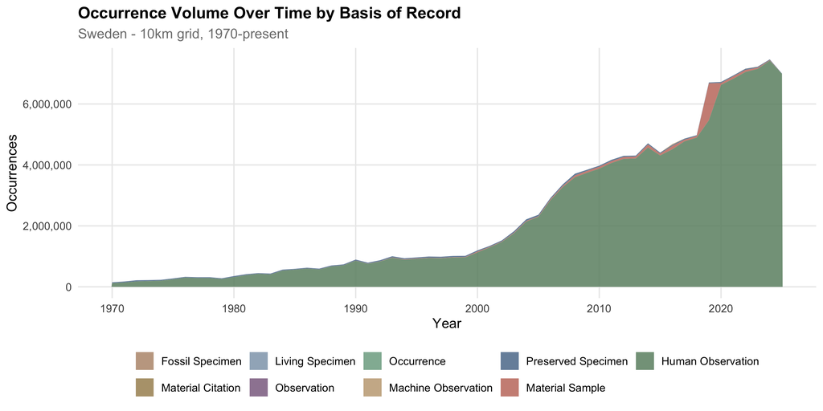

```r
if (!is.null(time_summary)) {
  year_by_basis <- time_summary[
    basisofrecord != "all" & !is.na(year) & year >= 1970,
    .(occurrences = sum(as.numeric(occurrences), na.rm = TRUE)),
    by = .(basisofrecord, year)
  ]

  # Order by total volume
  basis_order <- year_by_basis[, .(tot = sum(as.numeric(occurrences))), by = basisofrecord][order(-tot)]
  year_by_basis[, basisofrecord := factor(basisofrecord, levels = rev(basis_order$basisofrecord))]
  year_by_basis[, label := basis_label(as.character(basisofrecord))]

  ggplot(year_by_basis, aes(x = year, y = occurrences, fill = basisofrecord)) +
    geom_area(alpha = 0.85) +
    scale_fill_manual(values = basis_palette, labels = basis_label) +
    scale_y_continuous(labels = comma) +
    labs(title = "Occurrence Volume Over Time by Basis of Record",
         subtitle = paste0(country_name, " - ", params$grid, " grid, 1970-present"),
         x = "Year", y = "Occurrences", fill = NULL) +
    theme(legend.position = "bottom") +
    guides(fill = guide_legend(nrow = 2))
}
```

## Annual Trend (Proportional)

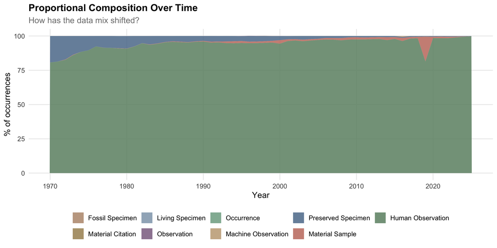

```r
if (!is.null(time_summary)) {
  year_by_basis_pct <- year_by_basis[,
    .(basisofrecord, label, pct = as.numeric(occurrences) / sum(as.numeric(occurrences)) * 100),
    by = year
  ]

  ggplot(year_by_basis_pct, aes(x = year, y = pct, fill = basisofrecord)) +
    geom_area(alpha = 0.85) +
    scale_fill_manual(values = basis_palette, labels = basis_label) +
    labs(title = "Proportional Composition Over Time",
         subtitle = "How has the data mix shifted?",
         x = "Year", y = "% of occurrences", fill = NULL) +
    theme(legend.position = "bottom") +
    guides(fill = guide_legend(nrow = 2))
}
```

## Seasonal Patterns

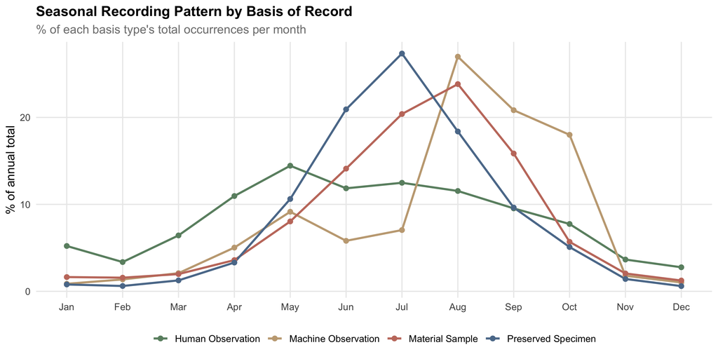

```r
if (!is.null(time_summary)) {
  month_by_basis <- time_summary[
    basisofrecord != "all" & !is.na(month) & month >= 1 & month <= 12,
    .(occurrences = sum(as.numeric(occurrences), na.rm = TRUE)),
    by = .(basisofrecord, month)
  ]

  # Normalise within each basis
  month_by_basis[, pct := as.numeric(occurrences) / sum(as.numeric(occurrences)) * 100, by = basisofrecord]

  # Top 4 basis types only
  top4 <- month_by_basis[, .(tot = sum(as.numeric(occurrences))), by = basisofrecord][order(-tot)]$basisofrecord[1:4]
  month_by_basis_top <- month_by_basis[basisofrecord %in% top4]
  month_by_basis_top[, label := basis_label(basisofrecord)]

  ggplot(month_by_basis_top, aes(x = month, y = pct, colour = basisofrecord)) +
    geom_line(linewidth = 1) +
    geom_point(size = 2) +
    scale_colour_manual(values = basis_palette, labels = basis_label) +
    scale_x_continuous(breaks = 1:12, labels = month.abb) +
    labs(title = "Seasonal Recording Pattern by Basis of Record",
         subtitle = "% of each basis type's total occurrences per month",
         x = NULL, y = "% of annual total", colour = NULL) +
    theme(legend.position = "bottom")
}
```

# Species Coverage

Which basis types record the most species? And how unique is each - do preserved specimens capture species missed by human observations?

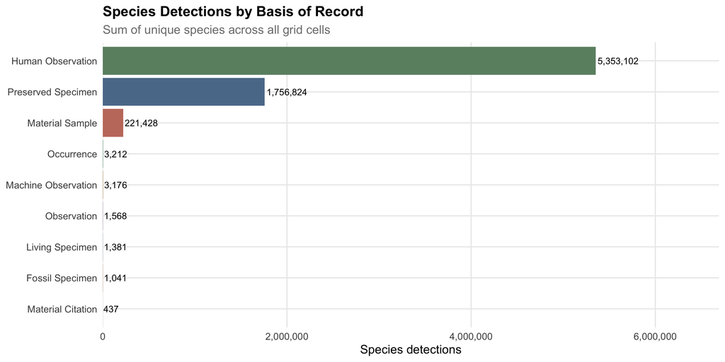

```r
if (!is.null(spatial_gaps)) {
  species_df <- spatial_gaps[basisofrecord != "all",
    .(total_species = sum(as.numeric(n_species), na.rm = TRUE)),
    by = basisofrecord
  ][order(-total_species)]

  species_df[, label := basis_label(basisofrecord)]

  ggplot(species_df, aes(x = reorder(label, total_species), y = total_species,
                          fill = basisofrecord)) +
    geom_col(show.legend = FALSE) +
    geom_text(aes(label = comma(total_species)), hjust = -0.05, size = 3.2) +
    scale_fill_manual(values = basis_palette) +
    scale_y_continuous(labels = comma, expand = expansion(mult = c(0, 0.25))) +
    coord_flip() +
    labs(title = "Species Detections by Basis of Record",
         subtitle = "Sum of unique species across all grid cells",
         x = NULL, y = "Species detections")
}
```

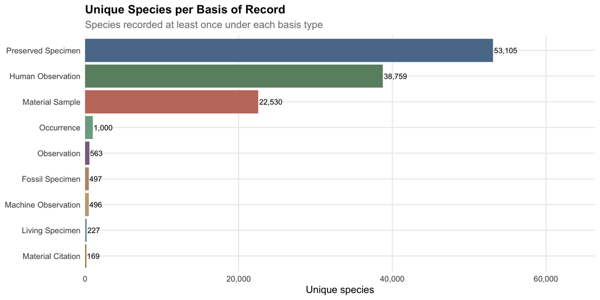

```r
# Compute unique species per basis using cell-level data
# (species detected in at least one cell)
if (!is.null(spatial_gaps)) {
  # Read species_cell files to get actual species lists per basis
  p_cell_order <- here(p_derived, "by_order", "species_cell")
  p_cell_family <- here(p_derived, "by_family", "species_cell")

  cell_files <- c(
    if (dir.exists(p_cell_order)) list.files(p_cell_order, pattern = paste0(params$grid, "\\.csv$"), full.names = TRUE) else character(0),
    if (dir.exists(p_cell_family)) list.files(p_cell_family, pattern = paste0(params$grid, "\\.csv$"), full.names = TRUE) else character(0)
  )

  if (length(cell_files) > 0 && length(cell_files) <= 2000) {
    basis_species <- rbindlist(lapply(cell_files, function(f) {
      dt <- fread(f, select = c("basisofrecord", "species"))
      dt[basisofrecord != "all", .(species = unique(species)), by = basisofrecord]
    }))
    basis_species <- unique(basis_species)

    sp_counts <- basis_species[, .(n_unique = uniqueN(species)), by = basisofrecord][order(-n_unique)]
    sp_counts[, label := basis_label(basisofrecord)]

    ggplot(sp_counts, aes(x = reorder(label, n_unique), y = n_unique, fill = basisofrecord)) +
      geom_col(show.legend = FALSE) +
      geom_text(aes(label = comma(n_unique)), hjust = -0.05, size = 3.2) +
      scale_fill_manual(values = basis_palette) +
      scale_y_continuous(labels = comma, expand = expansion(mult = c(0, 0.25))) +
      coord_flip() +
      labs(title = "Unique Species per Basis of Record",
           subtitle = "Species recorded at least once under each basis type",
           x = NULL, y = "Unique species")
  }
}
```

# Taxonomic Coverage by Basis

How well does each basis of record cover the national taxonomic backbone? This shows whether museum specimens and citizen science records document different parts of the tree of life.

```r
if (!is.null(tax_by_basis)) {
  tax_df <- as_tibble(tax_by_basis)

  if ("basisofrecord" %in% names(tax_df) && "pct_coverage" %in% names(tax_df)) {
    tax_df <- tax_df |> filter(basisofrecord != "all")

    ggplot(tax_df, aes(x = reorder(basis_label(basisofrecord), pct_coverage),
                        y = pct_coverage, fill = basisofrecord)) +
      geom_col(show.legend = FALSE) +
      geom_text(aes(label = paste0(round(pct_coverage, 1), "%")), hjust = -0.1, size = 3.5) +
      scale_fill_manual(values = basis_palette) +
      scale_y_continuous(limits = c(0, 105)) +
      coord_flip() +
      labs(title = "Taxonomic Backbone Coverage by Basis of Record",
           subtitle = paste0("% of ", country_name, " national checklist species detected"),
           x = NULL, y = "% of checklist species covered")
  }
}
```

[output not shown]

# Complementarity Analysis

Different basis types often complement each other. Preserved specimens may cover taxa poorly represented in citizen science data, and vice versa.

```r
if (exists("basis_species") && nrow(basis_species) > 0) {
  # Top 3 basis types
  top3 <- sp_counts$basisofrecord[1:min(3, nrow(sp_counts))]

  if (length(top3) >= 2) {
    sp_lists <- lapply(top3, function(b) unique(basis_species[basisofrecord == b]$species))
    names(sp_lists) <- basis_label(top3)

    # Pairwise overlap
    overlap_df <- expand.grid(
      basis1 = names(sp_lists), basis2 = names(sp_lists),
      stringsAsFactors = FALSE
    ) |>
      filter(basis1 != basis2) |>
      rowwise() |>
      mutate(
        n1 = length(sp_lists[[basis1]]),
        n2 = length(sp_lists[[basis2]]),
        shared = length(intersect(sp_lists[[basis1]], sp_lists[[basis2]])),
        only_in_1 = length(setdiff(sp_lists[[basis1]], sp_lists[[basis2]])),
        pct_shared = round(100 * shared / n1, 1)
      ) |>
      ungroup()

    overlap_df |>
      select(basis1, basis2, n1, shared, only_in_1, pct_shared) |>
      rename(
        `Basis A` = basis1,
        `Basis B` = basis2,
        `Species in A` = n1,
        `Shared` = shared,
        `Only in A` = only_in_1,
        `% of A shared` = pct_shared
      ) |>
      kable()
  }
}
```

| Basis A | Basis B | Species in A | Shared | Only in A | % of A shared |
| --- | --- | --- | --- | --- | --- |
| Human Observation | Preserved Specimen | 38759 | 33705 | 5054 | 87.0 |
| Material Sample | Preserved Specimen | 22530 | 12976 | 9554 | 57.6 |
| Preserved Specimen | Human Observation | 53105 | 33705 | 19400 | 63.5 |
| Material Sample | Human Observation | 22530 | 11617 | 10913 | 51.6 |
| Preserved Specimen | Material Sample | 53105 | 12976 | 40129 | 24.4 |
| Human Observation | Material Sample | 38759 | 11617 | 27142 | 30.0 |

# Data Quality Indicators

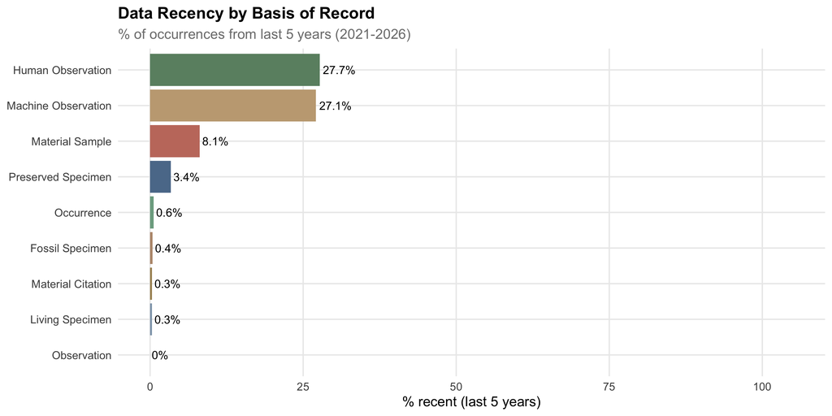

```r
if (!is.null(time_summary)) {
  # Compute recency per basis type safely (avoids integer overflow and type conflicts)
  basis_types <- unique(time_summary[basisofrecord != "all" & !is.na(year)]$basisofrecord)

  recency_list <- lapply(basis_types, function(b) {
    bd <- time_summary[basisofrecord == b & !is.na(year)]
    total <- sum(as.numeric(bd$occurrences), na.rm = TRUE)
    if (total == 0) return(NULL)

    recent_5  <- sum(as.numeric(bd[year >= current_year - 5]$occurrences), na.rm = TRUE)
    recent_10 <- sum(as.numeric(bd[year >= current_year - 10]$occurrences), na.rm = TRUE)

    # Weighted median: cumulative sum approach (no rep() needed)
    yearly <- bd[, .(occ = sum(as.numeric(occurrences), na.rm = TRUE)), by = year][order(year)]
    yearly[, cum := cumsum(occ)]
    half <- sum(yearly$occ) / 2
    med_year <- yearly$year[which(yearly$cum >= half)[1]]

    data.table(
      basisofrecord   = b,
      median_year     = as.numeric(med_year),
      pct_recent_5yr  = round(100 * recent_5 / total, 1),
      pct_recent_10yr = round(100 * recent_10 / total, 1)
    )
  })

  recent_by_basis <- rbindlist(recency_list)[order(-pct_recent_5yr)]
  recent_by_basis[, label := basis_label(basisofrecord)]

  ggplot(recent_by_basis,
         aes(x = reorder(label, pct_recent_5yr), y = pct_recent_5yr,
             fill = basisofrecord)) +
    geom_col(show.legend = FALSE) +
    geom_text(aes(label = paste0(pct_recent_5yr, "%")), hjust = -0.1, size = 3.5) +
    scale_fill_manual(values = basis_palette) +
    scale_y_continuous(limits = c(0, 105)) +
    coord_flip() +
    labs(title = "Data Recency by Basis of Record",
         subtitle = glue("% of occurrences from last 5 years ({current_year - 5}-{current_year})"),
         x = NULL, y = "% recent (last 5 years)")
}
```

```r
if (exists("recent_by_basis")) {
  recent_by_basis |>
    select(label, median_year, pct_recent_5yr, pct_recent_10yr) |>
    rename(
      `Basis of Record` = label,
      `Median Year` = median_year,
      `% Last 5 Years` = pct_recent_5yr,
      `% Last 10 Years` = pct_recent_10yr
    ) |>
    kable()
}
```

| Basis of Record | Median Year | % Last 5 Years | % Last 10 Years |
| --- | --- | --- | --- |
| Human Observation | 2015 | 27.7 | 48.3 |
| Machine Observation | 2016 | 27.1 | 90.6 |
| Material Sample | 2019 | 8.1 | 66.8 |
| Preserved Specimen | 1969 | 3.4 | 7.4 |
| Occurrence | 1947 | 0.6 | 1.5 |
| Fossil Specimen | 1922 | 0.4 | 0.4 |
| Living Specimen | 2001 | 0.3 | 6.9 |
| Material Citation | 2011 | 0.3 | 33.7 |
| Observation | 1995 | 0.0 | 0.0 |

# Key Findings

```r
if (!is.null(spatial_gaps) && exists("basis_totals")) {
  dominant <- basis_totals[1, ]
  cat(paste0(
    "- **Dominant data source**: ", basis_label(dominant$basisofrecord),
    " accounts for ", dominant$pct, "% of all occurrences (",
    comma(dominant$total_occurrences), " records)\n"
  ))

  best_coverage <- coverage_df[1, ]
  cat(paste0(
    "- **Best spatial coverage**: ", basis_label(best_coverage$basisofrecord),
    " covers ", best_coverage$pct, "% of grid cells\n"
  ))

  if (exists("recent_by_basis")) {
    most_recent <- recent_by_basis[1, ]
    cat(paste0(
      "- **Most current data**: ", most_recent$label,
      " has ", most_recent$pct_recent_5yr, "% of records from the last 5 years\n"
    ))

    oldest <- recent_by_basis[.N, ]
    cat(paste0(
      "- **Most historical data**: ", oldest$label,
      " has a median year of ", round(oldest$median_year),
      " (only ", oldest$pct_recent_5yr, "% from the last 5 years)\n"
    ))
  }
}
```

[output not shown]

*Report generated by `gbifgaps` on 2026-03-17 16:12.*